# Biostat 203B Homework 4

Due Mar 24 @ 11:59PM

Author

Load database libraries and the tidyverse frontend:

```r
# install.packages("bonsai")
library(GGally)
library(gtsummary)
# library(keras)
# install_keras()
library(bonsai)
library(lightgbm)
suppressPackageStartupMessages(library(tidyverse))
suppressPackageStartupMessages(library(tidymodels))
suppressPackageStartupMessages(library(lubridate))
```

# 1 Predicting 30-day mortality

Using the ICU cohort `icu_cohort.rds` you built in Homework 3, develop at least three analytic approaches for predicting the 30-day mortality of patients admitted to ICU using demographic information (gender, age, marital status, ethnicity), first lab measurements during ICU stay, and first vital measurements during ICU stay. For example, you can use (1) logistic regression with elastic net (lasso + ridge) penalty (e.g., glmnet or keras package), (2) random forest, (3) boosting, and (4) support vector machines, or (5) MLP neural network (keras package)

1. Partition data into 50% training set and 50% test set. Stratify partitioning according the 30-day mortality status.
2. Train and tune the models using the training set.
3. Compare model classification performance on the test set. Report both the area under ROC curve and accuracy for each model.

# 2 Solution

## 2.1 Load and setup data

```r
icu_data_path <- "../hw3/mimiciv_shiny/data/icu_cohort.rds"
cohort_data <- read_rds(icu_data_path)

cohort_data %>% print(width = Inf)
```

```
# A tibble: 53,150 × 41
   subject_id intime               hadm_id  stay_id first_careunit
        <int> <dttm>                 <int>    <int> <chr>
 1   12776735 2200-07-12 00:33:00 20817525 34547665 Neuro Stepdown
 2   16256226 2150-12-20 16:09:08 20013290 39289362 Neuro Stepdown
 3   12974563 2138-11-13 23:30:01 29618057 32563675 Neuro Stepdown
 4   14609218 2174-06-28 21:13:00 20606189 34947848 Neuro Stepdown
 5   12687112 2162-05-31 18:08:45 26132667 37445058 Neuro Stepdown
 6   18190935 2115-11-12 23:23:32 21137829 34338402 Neuro Stepdown
 7   10404210 2161-03-03 18:30:00 22880512 30254828 Neuro Stepdown
 8   12552973 2135-09-21 18:12:03 21320643 30261549 Neuro Stepdown
 9   14303051 2175-11-20 01:02:00 26559537 30401486 Neuro Stepdown
10   12347959 2140-07-11 17:54:14 22779073 30503984 Neuro Stepdown
   last_careunit  outtime               los admittime
   <chr>          <dttm>              <dbl> <dttm>
```

[output cut: 107 more lines]

Drop all id columns and variables related to discharge.

```r
cohort_cleaned <- cohort_data %>%
  select(-subject_id,
  -hadm_id,
  -stay_id,
  -intime,
  -last_careunit,
  -outtime,
  -los,
  -dischtime,
  -deathtime,
  -discharge_location,
  -edregtime,
  -edouttime,
  -hospital_expire_flag,
  -anchor_age,
  -anchor_year,
  -anchor_year_group,
  -dod) %>%
  mutate(
    admit_hour = hour(admittime),
    thirty_day_mort = as.factor(thirty_day_mort)
  ) %>%
  select(
    -admittime
  ) %>%
  print(width = Inf)
```

```
# A tibble: 53,150 × 24
   first_careunit admission_type              admission_location     insurance
   <chr>          <chr>                       <chr>                  <chr>
 1 Neuro Stepdown OBSERVATION ADMIT           EMERGENCY ROOM         Medicare
 2 Neuro Stepdown SURGICAL SAME DAY ADMISSION PHYSICIAN REFERRAL     Other
 3 Neuro Stepdown OBSERVATION ADMIT           EMERGENCY ROOM         Other
 4 Neuro Stepdown OBSERVATION ADMIT           EMERGENCY ROOM         Other
 5 Neuro Stepdown OBSERVATION ADMIT           PHYSICIAN REFERRAL     Other
 6 Neuro Stepdown OBSERVATION ADMIT           TRANSFER FROM HOSPITAL Other
 7 Neuro Stepdown OBSERVATION ADMIT           EMERGENCY ROOM         Other
 8 Neuro Stepdown SURGICAL SAME DAY ADMISSION PHYSICIAN REFERRAL     Other
 9 Neuro Stepdown OBSERVATION ADMIT           EMERGENCY ROOM         Other
10 Neuro Stepdown URGENT                      TRANSFER FROM HOSPITAL Other
   language marital_status ethnicity              gender   age chloride
   <chr>    <chr>          <chr>                  <chr>  <int>    <dbl>
```

[output cut: 47 more lines]

We choose to coalesce all categorical variables having levels with fewer than 3% of that variable’s total number of patients into “other” categories for these variables.

```r
lump_prop = 0.03

cohort_cleaned <- cohort_cleaned %>%
  mutate(
    first_careunit = fct_lump_prop(first_careunit, lump_prop),
    admission_type = fct_lump_prop(admission_type, lump_prop),
    admission_location = fct_lump_prop(admission_location, lump_prop),
    ethnicity = fct_lump_prop(ethnicity, 0.028) # I want to keep Asian separate
  )

cohort_cleaned %>% tbl_summary(thirty_day_mort)
```

| **Characteristic** | **0**, N = 47,953<sup>1</sup> | **1**, N = 5,197<sup>1</sup> |
| --- | --- | --- |
| first_careunit |  |  |
| Cardiac Vascular Intensive Care Unit (CVICU) | 9,193 (19%) | 257 (4.9%) |
| Coronary Care Unit (CCU) | 5,386 (11%) | 714 (14%) |
| Medical Intensive Care Unit (MICU) | 8,855 (18%) | 1,378 (27%) |
| Medical/Surgical Intensive Care Unit (MICU/SICU) | 7,783 (16%) | 1,050 (20%) |
| Surgical Intensive Care Unit (SICU) | 7,369 (15%) | 880 (17%) |
| Trauma SICU (TSICU) | 6,310 (13%) | 655 (13%) |
| Other | 3,057 (6.4%) | 263 (5.1%) |
| admission_type |  |  |
| DIRECT EMER. | 1,690 (3.5%) | 149 (2.9%) |
| ELECTIVE | 1,965 (4.1%) | 36 (0.7%) |
| EW EMER. | 23,894 (50%) | 3,163 (61%) |
| OBSERVATION ADMIT | 5,609 (12%) | 546 (11%) |
| SURGICAL SAME DAY ADMISSION | 5,798 (12%) | 77 (1.5%) |
| URGENT | 8,595 (18%) | 1,185 (23%) |
| Other | 402 (0.8%) | 41 (0.8%) |
| admission_location |  |  |
| EMERGENCY ROOM | 22,305 (47%) | 2,882 (55%) |
| PHYSICIAN REFERRAL | 11,819 (25%) | 473 (9.1%) |
| TRANSFER FROM HOSPITAL | 10,869 (23%) | 1,536 (30%) |
| Other | 2,960 (6.2%) | 306 (5.9%) |
| insurance |  |  |
| Medicaid | 3,540 (7.4%) | 297 (5.7%) |
| Medicare | 20,020 (42%) | 2,756 (53%) |
| Other | 24,393 (51%) | 2,144 (41%) |
| language |  |  |
| ? | 4,735 (9.9%) | 559 (11%) |
| ENGLISH | 43,218 (90%) | 4,638 (89%) |
| marital_status |  |  |
| DIVORCED | 3,399 (7.7%) | 296 (7.1%) |
| MARRIED | 22,069 (50%) | 2,043 (49%) |
| SINGLE | 13,243 (30%) | 999 (24%) |
| WIDOWED | 5,630 (13%) | 840 (20%) |
| Unknown | 3,612 | 1,019 |
| ethnicity |  |  |
| ASIAN | 1,404 (2.9%) | 160 (3.1%) |
| BLACK/AFRICAN AMERICAN | 4,495 (9.4%) | 379 (7.3%) |
| HISPANIC/LATINO | 1,712 (3.6%) | 115 (2.2%) |
| OTHER | 2,327 (4.9%) | 210 (4.0%) |
| UNKNOWN | 4,697 (9.8%) | 1,130 (22%) |
| WHITE | 32,591 (68%) | 3,077 (59%) |
| Other | 727 (1.5%) | 126 (2.4%) |
| gender |  |  |
| F | 20,946 (44%) | 2,407 (46%) |
| M | 27,007 (56%) | 2,790 (54%) |
| age | 66 (53, 77) | 74 (61, 84) |
| chloride | 105 (101, 108) | 104 (99, 108) |
| Unknown | 1,341 | 424 |
| creatinine | 0.90 (0.70, 1.20) | 1.30 (0.85, 2.10) |
| Unknown | 1,355 | 430 |
| white_blood_cells | 10.4 (7.5, 14.2) | 12.6 (8.6, 18.1) |
| Unknown | 1,696 | 463 |
| potassium | 4.10 (3.70, 4.50) | 4.20 (3.70, 4.80) |
| Unknown | 1,364 | 425 |
| hematocrit | 33 (28, 37) | 32 (27, 37) |
| Unknown | 1,576 | 460 |
| sodium | 139.0 (136.0, 141.0) | 139.0 (135.0, 142.0) |
| Unknown | 1,337 | 421 |
| bicarbonate | 23.0 (21.0, 25.0) | 21.0 (17.0, 24.0) |
| Unknown | 1,375 | 430 |
| glucose | 123 (103, 153) | 140 (108, 189) |
| Unknown | 1,448 | 432 |
| non_invasive_blood_pressure_mean | 81 (70, 93) | 78 (66, 93) |
| Unknown | 447 | 257 |
| non_invasive_blood_pressure_systolic | 122 (107, 139) | 117 (100, 137) |
| Unknown | 424 | 259 |
| temperature_fahrenheit | 98.20 (97.60, 98.70) | 98.00 (97.40, 98.70) |
| Unknown | 480 | 474 |
| respiratory_rate | 18.0 (14.0, 22.0) | 20.0 (16.0, 25.0) |
| Unknown | 54 | 8 |
| heart_rate | 84 (74, 98) | 92 (77, 108) |
| Unknown | 13 | 2 |
| admit_hour | 14 (6, 19) | 16 (8, 20) |

<sup>1</sup> n (%); Median (IQR)

### 2.1.1 Train/test split

```r
set.seed(100)
data_split <- initial_split(
  cohort_cleaned,
  strata = thirty_day_mort,
  prop = 0.5
)
data_split
```

```
<Training/Testing/Total>
<26575/26575/53150>
```

```r
cohort_train <- training(data_split)
dim(cohort_train)
```

```
[1] 26575    24
```

```r
cohort_test <- testing(data_split)
dim(cohort_test)
```

```
[1] 26575    24
```

## 2.2 Data processing recipes

We think lab and vital measurements will be important for preidcting mortality, and choose to impute missing values here using medians.

```r
recipe_with_normalization_and_dummies <- recipe(
  thirty_day_mort ~ .,
  data = cohort_train
  ) %>%
  step_impute_median(all_numeric_predictors(), -age) %>%
  step_unknown(all_nominal_predictors()) %>%
  step_normalize(all_numeric_predictors()) %>%
  step_dummy(all_nominal_predictors()) %>%
  step_zv(all_numeric_predictors()) %>%
  prep(training = cohort_train, retain = TRUE)



# recipe_with_
```

Our transformed data looks like this:

```r
baked_data <- bake(recipe_with_normalization_and_dummies, new_data = NULL)

baked_data %>% head()
```

```
# A tibble: 6 × 45
     age chloride creatinine white_blo…¹ potas…² hemat…³  sodium bicar…⁴ glucose
   <dbl>    <dbl>      <dbl>       <dbl>   <dbl>   <dbl>   <dbl>   <dbl>   <dbl>
1 -0.899   0.567     -0.558       -0.849  -0.248  -0.351  0.519   -0.460  -0.587
2  0.435  -0.0777    -0.204       -0.139   0.331   1.39   0.110   -1.61   -0.883
3 -1.07   -0.0777    -0.345       -0.839  -0.103   0.214 -0.0943   0.689  -0.587
4 -2.35    0.0834    -0.345       -0.489   0.186   0.309  0.110    0.229  -0.784
5 -0.899  -0.561     -0.416        0.811  -0.537   1.08  -0.299   -0.689  -0.601
6 -1.60   -1.04      -0.0618      -0.549  -0.537   1.60   0.110    1.61    0.341
# … with 36 more variables: non_invasive_blood_pressure_mean <dbl>,
#   non_invasive_blood_pressure_systolic <dbl>, temperature_fahrenheit <dbl>,
#   respiratory_rate <dbl>, heart_rate <dbl>, admit_hour <dbl>,
#   thirty_day_mort <fct>, first_careunit_Coronary.Care.Unit..CCU. <dbl>,
#   first_careunit_Medical.Intensive.Care.Unit..MICU. <dbl>,
#   first_careunit_Medical.Surgical.Intensive.Care.Unit..MICU.SICU. <dbl>,
#   first_careunit_Surgical.Intensive.Care.Unit..SICU. <dbl>, …
```

```r
# baked_data[which(is.na(baked_data)),]
```

## 2.3 Create prediction models with custom parameter grids

### 2.3.1 Logistic Regression

```r
logistic_model <- logistic_reg(
    penalty = tune(),
    mixture = tune()
  ) %>%
  set_engine("glmnet", standardize = FALSE)
logistic_model
```

```
Logistic Regression Model Specification (classification)

Main Arguments:
  penalty = tune()
  mixture = tune()

Engine-Specific Arguments:
  standardize = FALSE

Computational engine: glmnet
```

```r
logistic_grid <- grid_regular(
  penalty(),
  mixture(),
  levels = c(100, 5)
)
logistic_grid %>% head
```

```
# A tibble: 6 × 2
   penalty mixture
     <dbl>   <dbl>
1 1   e-10       0
2 1.26e-10       0
3 1.59e-10       0
4 2.01e-10       0
5 2.54e-10       0
6 3.20e-10       0
```

### 2.3.2 Random forest

```r
rf_model <- rand_forest(
    mode = "classification",
    mtry = tune(),
    trees = tune()
  ) %>%
  set_engine("ranger")
rf_model
```

```
Random Forest Model Specification (classification)

Main Arguments:
  mtry = tune()
  trees = tune()

Computational engine: ranger
```

```r
rf_grid <- grid_regular(
  trees(range = c(100, 300)),
  mtry(range = c(1, 5)),
  levels = c(3, 5)
)
rf_grid %>% head
```

```
# A tibble: 6 × 2
  trees  mtry
  <int> <int>
1   100     1
2   200     1
3   300     1
4   100     2
5   200     2
6   300     2
```

### 2.3.3 Boosted decision trees

Using `lightgbm` for speed in training rather than `xgboost`.

```r
boosted_model <- boost_tree(
  mode = "classification",
  trees = 1000,
  tree_depth = tune(),
  learn_rate = tune()
) %>%
  set_engine("lightgbm")
boosted_model
```

```
Boosted Tree Model Specification (classification)

Main Arguments:
  trees = 1000
  tree_depth = tune()
  learn_rate = tune()

Computational engine: lightgbm
```

```r
boosted_grid <- grid_regular(
  tree_depth(range = c(1L, 3L)),
  learn_rate(range = c(-5, 2), trans = log10_trans()),
  levels = c(3, 10)
)
boosted_grid %>% head
```

```
# A tibble: 6 × 2
  tree_depth learn_rate
       <int>      <dbl>
1          1  0.00001
2          2  0.00001
3          3  0.00001
4          1  0.0000599
5          2  0.0000599
6          3  0.0000599
```

### 2.3.4 Multilayer perceptron, 1 hidden layer

Note: Had bugs with keras on my M1 mac that I couldn’t debug (possibly related to `tensorflow-deps`?). Retaining model here as an example, but it is not used in the final workflowset.

```r
mlp_model <- mlp(
  mode = "classification",
  hidden_units = tune(),
  dropout = tune(),
  epochs = 20
) %>%
  set_engine("keras", verbose = 0)
mlp_model
```

```r
mlp_grid <- grid_regular(
  hidden_units(range = c(1, 20)),
  dropout(range = c(0, 0.6)),
  levels = 5
)
mlp_grid %>% head
```

## 2.4 Create workflowset with custom grids

We add a custom grid for each model, which in a workflowset will correspond to unique `workflow_id`s. So we have to specify a grid for each recipe-model pair.

```r
mimic_models <-
  workflow_set(
    preproc = list(simple = recipe_with_normalization_and_dummies),
    models = list(logit = logistic_model,
                  rf = rf_model,
                  # mlp = mlp_model,
                  boosted = boosted_model
                  ),
    cross = TRUE
  ) %>%

  # Add a unique parameter grid for each model type. Not all parameters are
  #   applicable for every model
  option_add(grid = logistic_grid, id = "simple_logit") %>%
  option_add(grid = rf_grid, id = "simple_rf") %>%
  # option_add(grid = mlp_grid, id = "simple_mlp") %>%
  option_add(grid = boosted_grid, id = "simple_boosted")
mimic_models
```

```
# A workflow set/tibble: 3 × 4
  wflow_id       info             option    result
  <chr>          <list>           <list>    <list>
1 simple_logit   <tibble [1 × 4]> <opts[1]> <list [0]>
2 simple_rf      <tibble [1 × 4]> <opts[1]> <list [0]>
3 simple_boosted <tibble [1 × 4]> <opts[1]> <list [0]>
```

## 2.5 Run cross-validation for all models in workflowset

Cross-validation splits

```r
cv_split <- vfold_cv(cohort_train, v = 5)
```

```r
st_time <- proc.time()

workflow_cv_fit <- mimic_models %>%
  workflow_map(
    resamples = cv_split,
    metrics = metric_set(roc_auc, accuracy),
    verbose = TRUE
  )

end_time <- proc.time()
print(end_time - st_time)
```

```
   user  system elapsed
372.556  13.502 370.782
```

```r
workflow_cv_fit
```

```
# A workflow set/tibble: 3 × 4
  wflow_id       info             option    result
  <chr>          <list>           <list>    <list>
1 simple_logit   <tibble [1 × 4]> <opts[3]> <tune[+]>
2 simple_rf      <tibble [1 × 4]> <opts[3]> <tune[+]>
3 simple_boosted <tibble [1 × 4]> <opts[3]> <tune[+]>
```

#### 2.5.0.1 Evaluate CV results

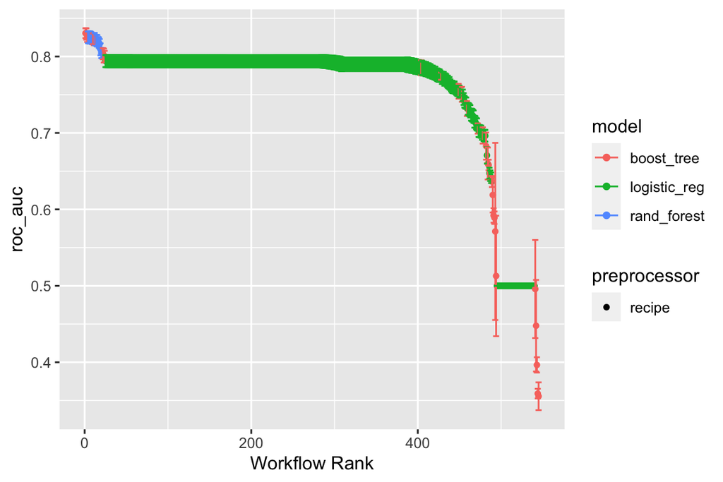

```r
autoplot(workflow_cv_fit, metric = "roc_auc")
```

```r
rank_results(workflow_cv_fit, rank_metric = "roc_auc", select_best = TRUE)
```

```
# A tibble: 6 × 9
  wflow_id       .config         .metric  mean std_err     n prepr…¹ model  rank
  <chr>          <chr>           <chr>   <dbl>   <dbl> <int> <chr>   <chr> <int>
1 simple_boosted Preprocessor1_… accura… 0.907 0.00146     5 recipe  boos…     1
2 simple_boosted Preprocessor1_… roc_auc 0.831 0.00391     5 recipe  boos…     1
3 simple_rf      Preprocessor1_… accura… 0.902 0.00162     5 recipe  rand…     2
4 simple_rf      Preprocessor1_… roc_auc 0.825 0.00470     5 recipe  rand…     2
5 simple_logit   Preprocessor1_… accura… 0.903 0.00181     5 recipe  logi…     3
6 simple_logit   Preprocessor1_… roc_auc 0.794 0.00477     5 recipe  logi…     3
# … with abbreviated variable name ¹preprocessor
```

#### 2.5.0.2 Hyperparameter performance per model

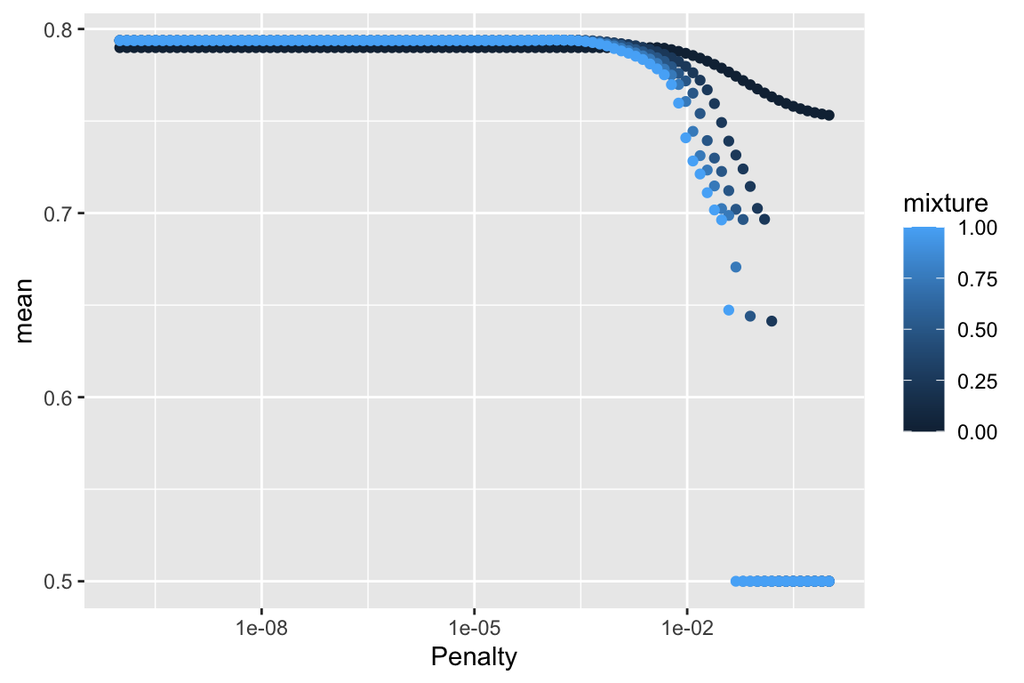

```r
# Logistic - penalty vs. mixture
workflow_cv_fit %>%
  extract_workflow_set_result(id = "simple_logit") %>%
  collect_metrics %>%
  filter(.metric == "roc_auc") %>%
  ggplot(aes(x = penalty, y = mean, color = mixture)) +
  geom_point() +
  labs(
    x = "Penalty",
    y = "Cross-validation AUC",
    title = "Logistic regression hyperparameter tuning results"
  ) %>%
  scale_x_log10
```

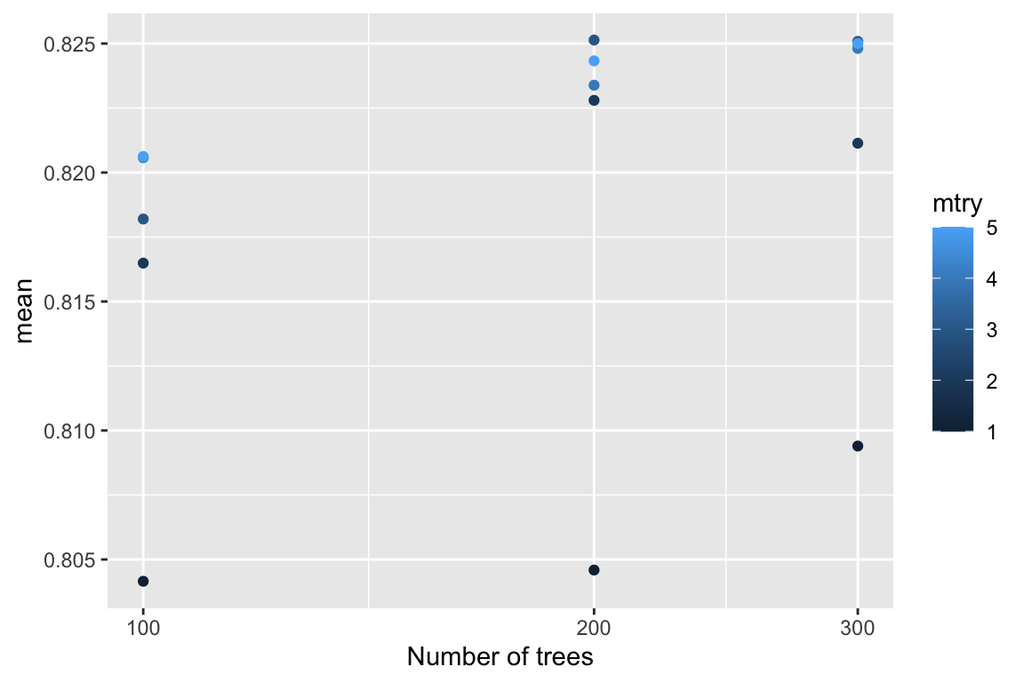

```r
# Logistic - trees vs. mtry
workflow_cv_fit %>%
  extract_workflow_set_result(id = "simple_rf") %>%
  collect_metrics %>%
  filter(.metric == "roc_auc") %>%
  ggplot(aes(x = trees, y = mean, color = mtry)) +
  geom_point() +
  labs(
    x = "Number of trees",
    y = "Cross-validation AUC",
    title = "Random forest hyperparameter tuning results"
  ) %>%
  scale_x_log10
```

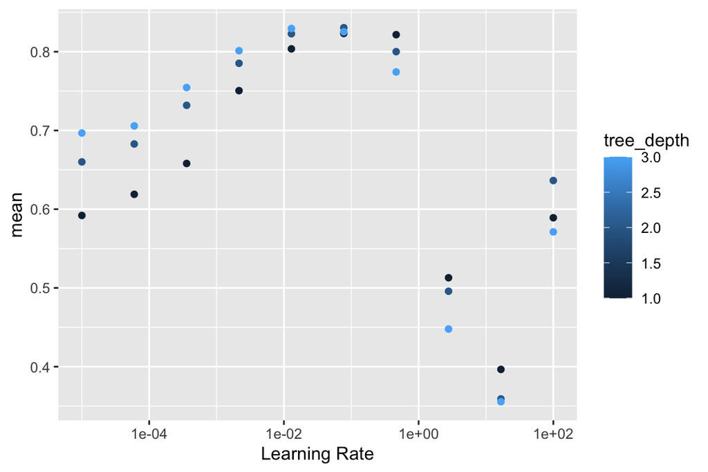

```r
# Boosted trees - learning rate vs. tree depth
workflow_cv_fit %>%
  extract_workflow_set_result(id = "simple_boosted") %>%
  collect_metrics %>%
  filter(.metric == "roc_auc")%>%
  ggplot(aes(x = learn_rate, y = mean, color = tree_depth)) +
  geom_point() +
  labs(
    x = "Learning Rate",
    y = "Cross-validation AUC",
    title = "LightGBM hyperparameter tuning results"
  ) %>%
  scale_x_log10
```

## 2.6 Finalize best model

What is the best workflow for each model type?

```r
best_workflows <- rank_results(workflow_cv_fit,
                               rank_metric = "roc_auc") %>%
  filter(.metric == "roc_auc") %>%
  group_by(model) %>%
  arrange(desc(mean)) %>%
  slice_head(n = 1) %>%
  print(width = Inf)
```

```
# A tibble: 3 × 9
# Groups:   model [3]
  wflow_id       .config                .metric  mean std_err     n preprocessor
  <chr>          <chr>                  <chr>   <dbl>   <dbl> <int> <chr>
1 simple_boosted Preprocessor1_Model17  roc_auc 0.831 0.00391     5 recipe
2 simple_logit   Preprocessor1_Model462 roc_auc 0.794 0.00477     5 recipe
3 simple_rf      Preprocessor1_Model08  roc_auc 0.825 0.00470     5 recipe
  model         rank
  <chr>        <int>
1 boost_tree       1
2 logistic_reg    25
3 rand_forest      4
```

Let’s finalize our models for each of these workflows. Note selecting the best workflow given a workflowset is an [open issue for tidymodels](https://github.com/tidymodels/workflowsets/issues/94).

```r
finalize_model_from_set <- function(fit_workflowset,
                                    workflow_id,
                                    cross_val_split) {
  best.config <- fit_workflowset %>%
    extract_workflow_set_result(workflow_id) %>%
    select_best("roc_auc")

  best <- fit_workflowset %>%
    extract_workflow(workflow_id) %>%
    finalize_workflow(best.config) %>%
    last_fit(cross_val_split)

  return(best)
}
```

Best logistic regression:

```r
best_logit <- finalize_model_from_set(workflow_cv_fit,
                                      "simple_logit",
                                      data_split)
best_logit %>% collect_metrics()
```

```
# A tibble: 2 × 4
  .metric  .estimator .estimate .config
  <chr>    <chr>          <dbl> <chr>
1 accuracy binary         0.905 Preprocessor1_Model1
2 roc_auc  binary         0.808 Preprocessor1_Model1
```

Best random forest:

```r
best_rf <- finalize_model_from_set(workflow_cv_fit,
                                   "simple_rf",
                                   data_split)
best_rf %>% collect_metrics()
```

```
# A tibble: 2 × 4
  .metric  .estimator .estimate .config
  <chr>    <chr>          <dbl> <chr>
1 accuracy binary         0.904 Preprocessor1_Model1
2 roc_auc  binary         0.837 Preprocessor1_Model1
```

Best lightgbm model:

```r
best_lightgbm <- finalize_model_from_set(workflow_cv_fit,
                                         "simple_boosted",
                                         data_split)
best_lightgbm %>% collect_metrics()
```

```
# A tibble: 2 × 4
  .metric  .estimator .estimate .config
  <chr>    <chr>          <dbl> <chr>
1 accuracy binary         0.910 Preprocessor1_Model1
2 roc_auc  binary         0.845 Preprocessor1_Model1
```